# Fitting Probability distribution in R

Discrete and Continuous random Variables

Eralda Gjika (Dhamo)

18 January 2021

# Fitting Probability distributions

# DATASET CYBER DATA

data used for this session are imported from: https://osf.io/aj7vr/

```r
# read the data and save it as "cyber.data"
head(cyber.data,10)
```

|  | week | event.count | avg.report.length |
| --- | --- | --- | --- |
| 1 | 1 | 8 | 435 |
| 2 | 2 | 11 | 443 |
| 3 | 3 | 2 | 1076 |
| 4 | 4 | 2 | 598 |
| 5 | 5 | 0 | 0 |
| 6 | 6 | 3 | 728 |
| 7 | 7 | 5 | 797 |
| 8 | 8 | 3 | 248 |
| 9 | 9 | 5 | 735 |
| 10 | 10 | 3 | 152 |

Because the data are weekly observations we can have as a first graph a time series plot.

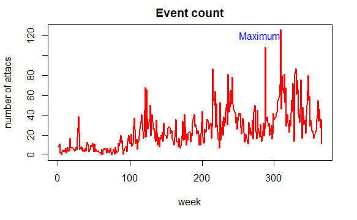

```r
library(forecast)
# ts.plot() will create a time series plot
ts.plot(cyber.data[,2],main="Event count", col="red",xlab="week", ylab="number of attacs",lwd=2)
text(280,120,"Maximum",col="blue")# will add text to our graph
```

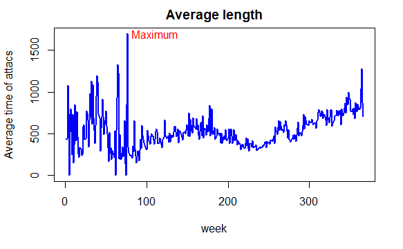

```r
ts.plot(cyber.data[,3],main="Average length", col="blue",xlab="week", ylab="Average time of attacs",lwd=2)
text(110,1700,"Maximum",col="red")
```

```r
summary(cyber.data[,c(2,3)])# descriptive statistics of our dataset
```

```
  event.count     avg.report.length
 Min.   :  0.00   Min.   :   0.0
 1st Qu.: 10.00   1st Qu.: 394.0
 Median : 21.00   Median : 509.0
 Mean   : 25.42   Mean   : 533.7
 3rd Qu.: 35.00   3rd Qu.: 654.0
 Max.   :126.00   Max.   :1700.0
```

Analyse the data by observing boxplot for any outliers.

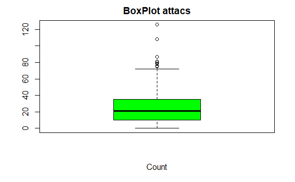

```r
boxplot(cyber.data[,2],col="green",main="BoxPlot attacs",xlab="Count")
```

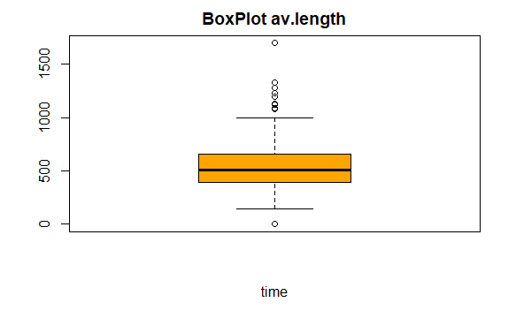

```r
boxplot(cyber.data[,3],col="orange",main="BoxPlot av.length",xlab="time")
#
par(mfrow=c(1,2))
```

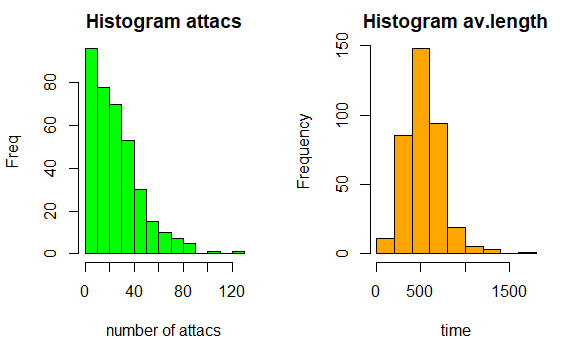

```r
hist(cyber.data[,2],col="green",main="Histogram attacs",xlab="number of attacs",ylab="Freq")
hist(cyber.data[,3],col="orange",main="Histogram av.length",xlab="time")
```

we observe some outliers in both variables, especially in the upper region. This was also observed in the time series plot. For now we are not dealing with this outliers . The aim of this material is just to show some basic functions from the library(fitdistr) and library(fitdistrplus) which are used for fitting probability distributions to a vector of numerical data.

# FITTING DISTRIBUTIONS IN R

Packages needed for this part are:

```r
library(fitdistrplus)
library(stats4)
library(MASS)
# for other necessary test or graphical tools
library(survival)
library(actuar)
library(distrMod)
```

### Probability density function (p.d.f) and Cummulative density function (c.d.f)

We can use the function plotdist(data) to obtain the histogram and the cummulative distribution graph of teh data.

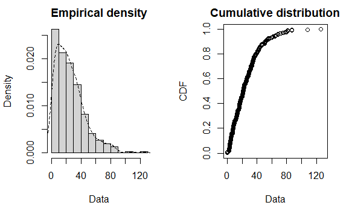

```r
plotdist(cyber.data$event.count, histo = TRUE, demp = TRUE)
```

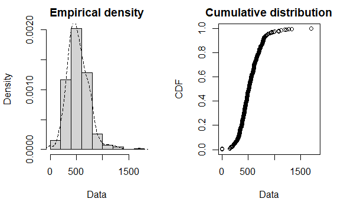

```r
plotdist(cyber.data$avg.report.length, histo = TRUE, demp = TRUE)
```

Exercise: Try to simulate 10^5 observations from the most known probability distributions you know and plot their Empirical density and Cummulative distribution. Are these graphs as you expected?

## Skewness-kurtosis graph for the choice of distributions (Cullen and Frey, 1999)

The function descdist() provides a skewness-kurtosis graph to help to choose the best candidate(s) to fit a given dataset. If we want to use it for discrete distributions we may use argument discrete=TRUE.

```
summary statistics
------
min:  0   max:  1700
median:  509
mean:  533.7213
estimated sd:  211.2284
estimated skewness:  1.014491
estimated kurtosis:  6.198751
```

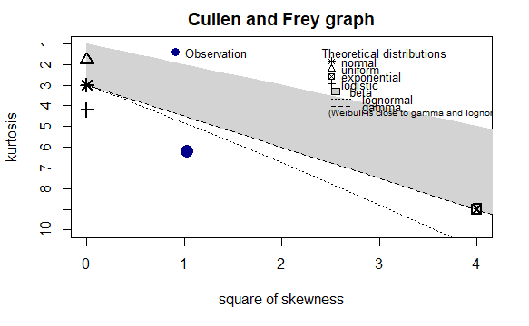

```r
descdist(cyber.data[,3])
```

```
summary statistics
------
min:  0   max:  1700
median:  509
mean:  533.7213
estimated sd:  211.2284
estimated skewness:  1.014491
estimated kurtosis:  6.198751
```

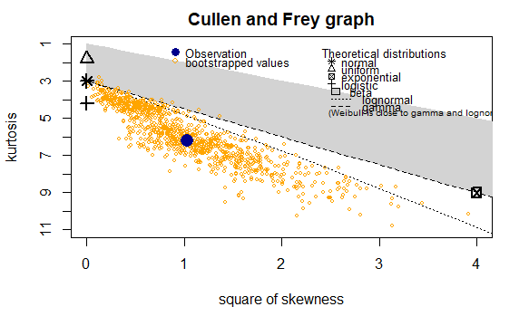

```r
descdist(cyber.data[,3], boot = 1000)# bootstrapped values 1000
```

```
summary statistics
------
min:  0   max:  1700
median:  509
mean:  533.7213
estimated sd:  211.2284
estimated skewness:  1.014491
estimated kurtosis:  6.198751
```

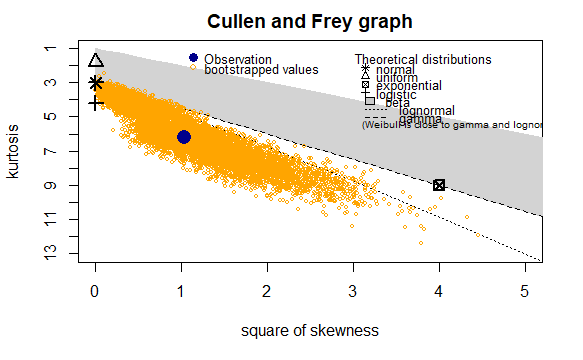

```r
descdist(cyber.data[,3], boot = 10000)# bootstrapped values 10^4
```

```
summary statistics
------
min:  0   max:  1700
median:  509
mean:  533.7213
estimated sd:  211.2284
estimated skewness:  1.014491
estimated kurtosis:  6.198751
```

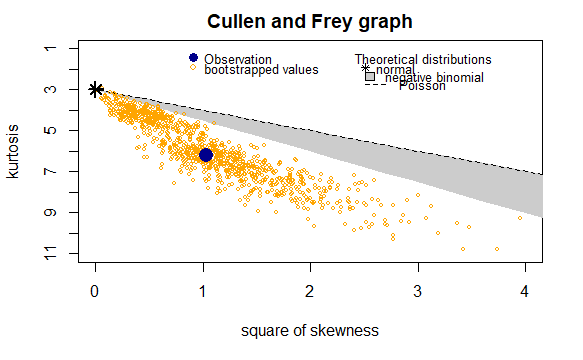

```r
# observe the concentration of the simulations
descdist(cyber.data[,3], boot = 1000,discrete=TRUE)
```

Trying to fit probability distributions to the number of cyber attacs.

```r
# Negative Binomial
nbinom.f<- fitdist(cyber.data$event.count, "nbinom")
```

```
NaNs producedNaNs producedNaNs produced
```

```r
pois.f<- fitdist(cyber.data$event.count, "pois")# Poisson
```

```
NaNs producedNaNs produced
```

```r
norm.f <- fitdist(cyber.data$event.count, "norm") # Normal
```

```
NaNs producedNaNs produced
```

```r
exp.f <- fitdist(cyber.data$event.count, "exp") # Exponential
```

```
NaNs producedNaNs produced
```

Information about the parameter estimation

```r
summary(nbinom.f)
```

```
Fitting of the distribution ' nbinom ' by maximum likelihood
Parameters :
```

|  | estimate | Std. Error |
| --- | --- | --- |
| size | 1.658441 | 0.1253352 |
| mu | 25.415193 | 1.0647008 |

```
Loglikelihood:  -1536.555   AIC:  3077.11   BIC:  3084.916
Correlation matrix:
             size           mu
size 1.000000e+00 7.175825e-06
mu   7.175825e-06 1.000000e+00
```

```r
summary(pois.f)
```

```
Fitting of the distribution ' pois ' by maximum likelihood
Parameters :
```

|  | estimate | Std. Error |
| --- | --- | --- |
| lambda | 25.4153 | 0.2635161 |

```
Loglikelihood:  -3522.192   AIC:  7046.384   BIC:  7050.287
```

```r
summary(norm.f)
```

```
Fitting of the distribution ' norm ' by maximum likelihood
Parameters :
```

|  | estimate | Std. Error |
| --- | --- | --- |
| mean | 25.41530 | 1.0361818 |
| sd | 19.82332 | 0.7326911 |

```
Loglikelihood:  -1612.522   AIC:  3229.044   BIC:  3236.849
Correlation matrix:
     mean sd
mean    1  0
sd      0  1
```

```r
summary(exp.f)
```

```
Fitting of the distribution ' exp ' by maximum likelihood
Parameters :
```

|  | estimate | Std. Error |
| --- | --- | --- |
| rate | 0.03934638 | 0.002055339 |

```
Loglikelihood:  -1550.139   AIC:  3102.277   BIC:  3106.18
```

### Compare the distributions

we can use these graphical test to compare the fitted distribiutions with the real observations. We expect the distributions to follow the patterns of teh real observations in the histogram, QQ-plot, CDF plot and also PP-plot.

```r
par(mfrow = c(2, 2))
plot.legend <- c("Binomial neg", "Poisson","Normal","Exponential")
denscomp(list(nbinom.f,pois.f,norm.f,exp.f), legendtext = plot.legend)
qqcomp(list(nbinom.f,pois.f,norm.f,exp.f), legendtext = plot.legend)
```

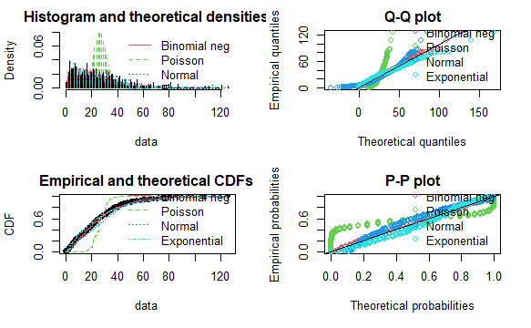

```r
cdfcomp(list(nbinom.f,pois.f,norm.f,exp.f), legendtext = plot.legend)
ppcomp(list(nbinom.f,pois.f,norm.f,exp.f), legendtext = plot.legend)
```

### Simulate based on the parameter estimated

Scatterplot view. we expect a high linear relationship.We use now the parameter estimated above to simulate random observations from these distributions. And we are using the scatterplot to understand the fitting. We are looking for scatterplots which show a linear pattern.

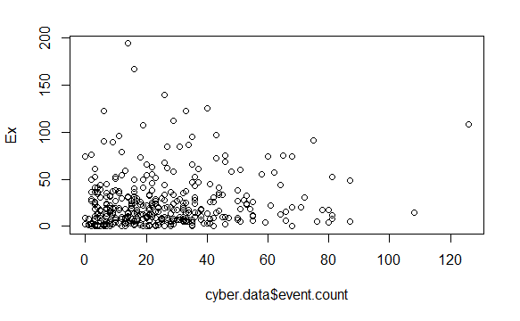

```r
set.seed(512)
Ex=rexp(length(cyber.data$event.count),0.03934638)# estimated rate= 0.03934638
plot(cyber.data$event.count,Ex)# scatterplot observed vs fitted
```

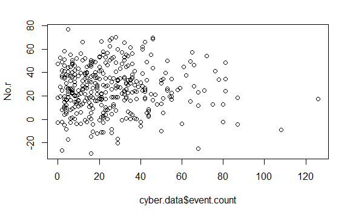

```r
No.r=rnorm(length(cyber.data$event.count),25.41530,19.82332) # estimated parameters
plot(cyber.data$event.count,No.r)#  scatterplot observed vs fitted
```

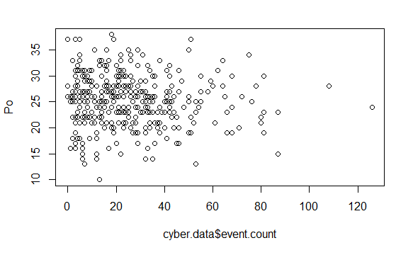

```r
Po=rpois(length(cyber.data$event.count),25.4153)# estimated parameters
plot(cyber.data$event.count,Po)#  scatterplot observed vs fitted
```

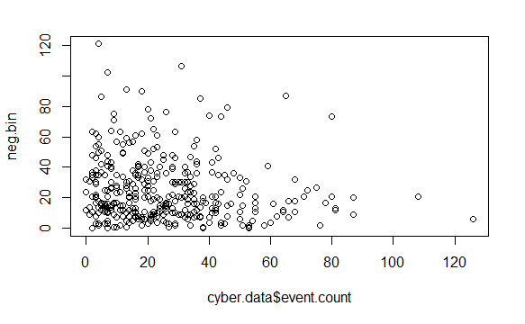

```r
neg.bin=rnbinom(length(cyber.data$event.count),size=1.658441, mu=25.415193)# estimated parameters
plot(cyber.data$event.count,neg.bin)#  scatterplot observed vs fitted
```

# Two fitted distribution

```r
par(mfrow = c(2, 2))
plot.legend <- c("Normal","Exponencial")
denscomp(list(norm.f,exp.f), legendtext = plot.legend)
qqcomp(list(norm.f,exp.f), legendtext = plot.legend)
```

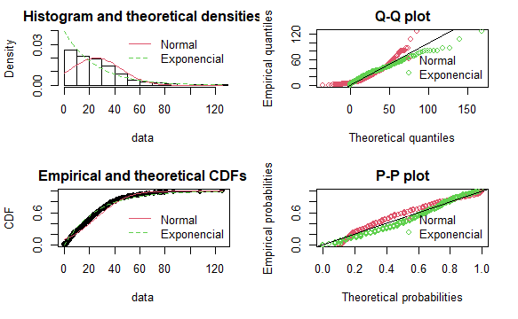

```r
cdfcomp(list(norm.f,exp.f), legendtext = plot.legend)
ppcomp(list(norm.f,exp.f), legendtext = plot.legend)
```

Compare the Negative Binomial fit and the normal fit.

```r
nbinom.f <- fitdist(cyber.data$event.count, "nbinom") #
```

```
NaNs producedNaNs producedNaNs produced
```

```r
norm.f <- fitdist(cyber.data$event.count, "norm") #
```

```
NaNs producedNaNs produced
```

```r
#
par(mfrow = c(2, 2))
plot.legend <- c("Binomial neg", "Normal")
denscomp(list(nbinom.f,norm.f), legendtext = plot.legend)
qqcomp(list(nbinom.f,norm.f), legendtext = plot.legend)
```

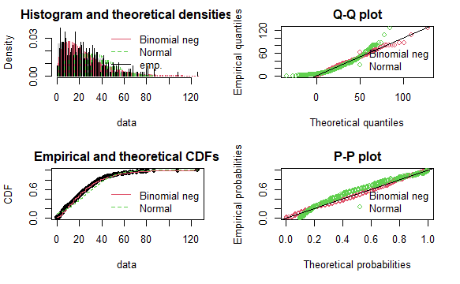

```r
cdfcomp(list(nbinom.f,norm.f), legendtext = plot.legend)
ppcomp(list(nbinom.f,norm.f), legendtext = plot.legend)
```

# Average time of attacks

```r
avg.report.length=ifelse(cyber.data$avg.report.length==0,0.01,cyber.data$avg.report.length)
expo.f <- fitdist(avg.report.length, "exp",method="mme")#
```

```
NaNs producedNaNs produced
```

```r
lnorm.f<- fitdist(avg.report.length, "lnorm",method="mme")#
```

```
NaNs producedNaNs produced
```

```r
norma.f<- fitdist(avg.report.length, "norm")#
```

```
NaNs producedNaNs produced
```

```r
weib <- fitdist(avg.report.length, "weibull", start = list(shape = 1, scale = 500))#
```

```
NaNs producedNaNs producedNaNs producedNaNs producedNaNs producedNaNs producedNaNs produced
```

```r
logis.f <- fitdist(avg.report.length, "llogis",start=NULL, fix.arg=NULL, discrete=FALSE, keepdata = TRUE)
```

[output not shown]

Cullen and Frey graph

```
summary statistics
------
min:  0.01   max:  1700
median:  509
mean:  533.7214
estimated sd:  211.2282
estimated skewness:  1.0145
estimated kurtosis:  6.198748
```

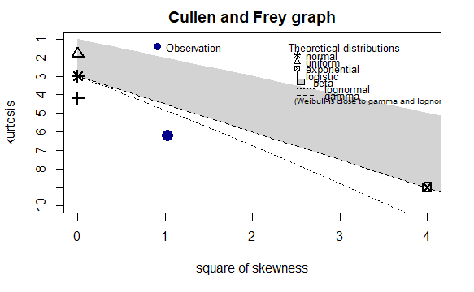

```r
descdist(avg.report.length)
```

```
summary statistics
------
min:  0.01   max:  1700
median:  509
mean:  533.7214
estimated sd:  211.2282
estimated skewness:  1.0145
estimated kurtosis:  6.198748
```

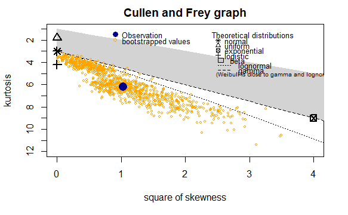

```r
descdist(avg.report.length, boot = 1000)# bootstrapped values 1000
```

```
summary statistics
------
min:  0.01   max:  1700
median:  509
mean:  533.7214
estimated sd:  211.2282
estimated skewness:  1.0145
estimated kurtosis:  6.198748
```

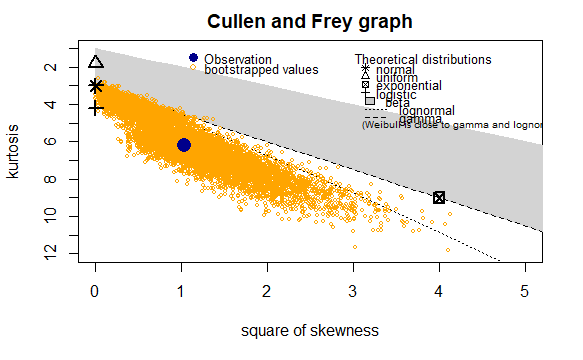

```r
descdist(avg.report.length, boot = 10000)# bootstrapped values 10^4
```

```
summary statistics
------
min:  0.01   max:  1700
median:  509
mean:  533.7214
estimated sd:  211.2282
estimated skewness:  1.0145
estimated kurtosis:  6.198748
```

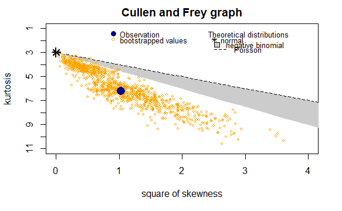

```r
# observe the concentration of the simulations
descdist(avg.report.length, boot = 1000,discrete=TRUE)
```

Parameter estimations:

```r
summary(expo.f)
```

```
Fitting of the distribution ' exp ' by matching moments
Parameters :
```

|  | estimate |
| --- | --- |
| rate | 0.001873637 |

```
Loglikelihood:  -2664.434   AIC:  5330.868   BIC:  5334.77
```

```r
summary(lnorm.f)
```

```
Fitting of the distribution ' lnorm ' by matching moments
Parameters :
```

|  | estimate |
| --- | --- |
| meanlog | 6.2073037 |
| sdlog | 0.3809731 |

```
Loglikelihood:  -3620.588   AIC:  7245.177   BIC:  7252.982
```

```r
summary(norma.f)
```

```
Fitting of the distribution ' norm ' by maximum likelihood
Parameters :
```

|  | estimate | Std. Error |
| --- | --- | --- |
| mean | 533.7214 | 11.025889 |
| sd | 210.9395 | 7.796508 |

```
Loglikelihood:  -2478.007   AIC:  4960.013   BIC:  4967.818
Correlation matrix:
     mean sd
mean    1  0
sd      0  1
```

```r
summary(weib)
```

```
Fitting of the distribution ' weibull ' by maximum likelihood
Parameters :
```

|  | estimate | Std. Error |
| --- | --- | --- |
| shape | 2.393026 | 0.09361555 |
| scale | 589.745354 | 13.43750405 |

```
Loglikelihood:  -2510.2   AIC:  5024.4   BIC:  5032.205
Correlation matrix:
          shape     scale
shape 1.0000000 0.2850167
scale 0.2850167 1.0000000
```

```r
summary(logis.f)
```

```
Fitting of the distribution ' llogis ' by maximum likelihood
Parameters :
```

|  | estimate | Std. Error |
| --- | --- | --- |
| shape | 3.602442 | 0.1607928 |
| scale | 502.731561 | 12.0151297 |

```
Loglikelihood:  -2538.638   AIC:  5081.277   BIC:  5089.082
Correlation matrix:
           shape      scale
shape 1.00000000 0.02488679
scale 0.02488679 1.00000000
```

Graphic test check:

```r
par(mfrow = c(2, 2))
plot.legend <- c("Exponential","Normal", "log-Normal","Weibull","Logis")
denscomp(list(expo.f,norma.f,lnorm.f,weib,logis.f), legendtext = plot.legend)
qqcomp(list(expo.f,norma.f,lnorm.f,weib,logis.f), legendtext = plot.legend)
```

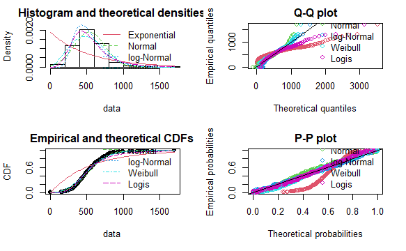

```r
cdfcomp(list(expo.f,norma.f,lnorm.f,weib,logis.f), legendtext = plot.legend)
ppcomp(list(expo.f,norma.f,lnorm.f,weib,logis.f), legendtext = plot.legend)
```

```r
#
gofstat(list(expo.f,norma.f,lnorm.f,weib,logis.f),fitnames = c("Exponential","Normal", "log-Normal","Weibull","Logis"))
```

```
Goodness-of-fit statistics
                             Exponential     Normal  log-Normal
Kolmogorov-Smirnov statistic   0.3433618 0.06189011  0.03403799
Cramer-von Mises statistic    13.4476900 0.42673770  0.14139236
Anderson-Darling statistic    66.2372441 2.74835073 11.17728575
                                Weibull      Logis
Kolmogorov-Smirnov statistic 0.09875598 0.08651839
Cramer-von Mises statistic   0.76792533 0.51785182
Anderson-Darling statistic   5.80145260 4.89002332

Goodness-of-fit criteria
                               Exponential   Normal log-Normal
Akaike's Information Criterion    5330.868 4960.013   7245.177
Bayesian Information Criterion    5334.770 4967.818   7252.982
                                Weibull    Logis
Akaike's Information Criterion 5024.400 5081.277
Bayesian Information Criterion 5032.205 5089.082
```